# biostat776-project1-Shengyuan-Luo

davidluoshy

2024-09-12

## Project 1 - setup

```r
library("here")
library("tidyverse")
```

```r
library("ggplot2")
```

Next I create a directory named “data.” The if statement helps avoid re-creating the directory if it already exists.

```r
if (!dir.exists(here("data"))) {
    dir.create(here("data"))
}
```

I use the following code to download the dataset. Again, the if statement checks if the dataset already exists. If so, data will not be re-downloaded.

```r
if (!file.exists(here("data", "chocolate.RDS"))) {
    url_csv <- "https://raw.githubusercontent.com/rfordatascience/tidytuesday/master/data/2022/2022-01-18/chocolate.csv"
    chocolate <- readr::read_csv(url_csv)

    # save the file to RDS objects
    saveRDS(chocolate, file = here("data", "chocolate.RDS"))
}
```

Making the dataset a tibble and taking a glimpse at the data.

```r
chocolate <- readRDS(here("data", "chocolate.RDS"))
as_tibble(chocolate)
```

```
## # A tibble: 2,530 × 10
##      ref company_manufacturer company_location review_date
##    <dbl> <chr>                <chr>                  <dbl>
##  1  2454 5150                 U.S.A.                  2019
##  2  2458 5150                 U.S.A.                  2019
##  3  2454 5150                 U.S.A.                  2019
##  4  2542 5150                 U.S.A.                  2021
##  5  2546 5150                 U.S.A.                  2021
##  6  2546 5150                 U.S.A.                  2021
##  7  2542 5150                 U.S.A.                  2021
##  8   797 A. Morin             France                  2012
##  9   797 A. Morin             France                  2012
## 10  1011 A. Morin             France                  2013
## # ℹ 2,520 more rows
## # ℹ 6 more variables: country_of_bean_origin <chr>,
## #   specific_bean_origin_or_bar_name <chr>, cocoa_percent <chr>,
## #   ingredients <chr>, most_memorable_characteristics <chr>, rating <dbl>
```

```r
glimpse(chocolate)
```

```
## Rows: 2,530
## Columns: 10
## $ ref                              <dbl> 2454, 2458, 2454, 2542, 2546, 2546, 2…
## $ company_manufacturer             <chr> "5150", "5150", "5150", "5150", "5150…
## $ company_location                 <chr> "U.S.A.", "U.S.A.", "U.S.A.", "U.S.A.…
## $ review_date                      <dbl> 2019, 2019, 2019, 2021, 2021, 2021, 2…
## $ country_of_bean_origin           <chr> "Tanzania", "Dominican Republic", "Ma…
## $ specific_bean_origin_or_bar_name <chr> "Kokoa Kamili, batch 1", "Zorzal, bat…
## $ cocoa_percent                    <chr> "76%", "76%", "76%", "68%", "72%", "8…
## $ ingredients                      <chr> "3- B,S,C", "3- B,S,C", "3- B,S,C", "…
## $ most_memorable_characteristics   <chr> "rich cocoa, fatty, bready", "cocoa, …
## $ rating                           <dbl> 3.25, 3.50, 3.75, 3.00, 3.00, 3.25, 3…
```

## Part 1: Explore data

1. Make a histogram of the `rating` scores to visualize the overall distribution of scores. Change the number of bins from the default to 10, 15, 20, and 25. Pick on the one that you think looks the best. Explain what the difference is when you change the number of bins and explain why you picked the one you did.

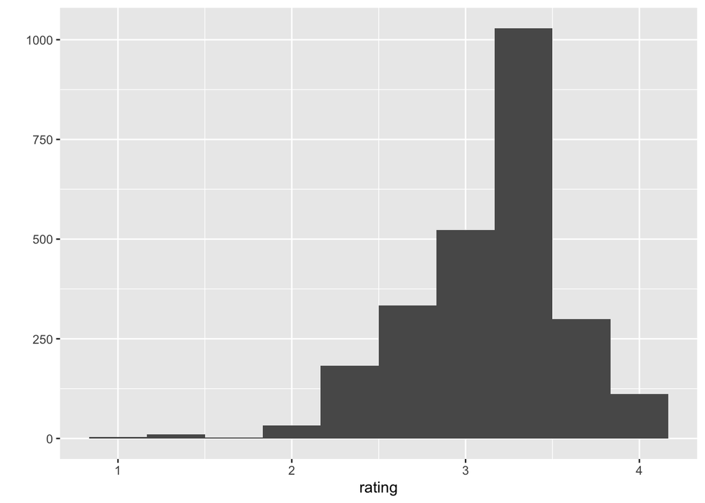

   ```r
   Figure1 <- qplot(rating, data = chocolate, bins =10)
   Figure1
   ```

   Number of bins set to 10. The histogram looks worse with more bins as categories with zero observations will start to appear.
2. Consider the countries where the beans originated from. How many reviews come from each country of bean origin?

   ```r
   chocolate  %>%
     count(country_of_bean_origin)
   ```

   ```
   ## # A tibble: 62 × 2
   ##    country_of_bean_origin     n
   ##    <chr>                  <int>
   ##  1 Australia                  3
   ##  2 Belize                    76
   ##  3 Blend                    156
   ##  4 Bolivia                   80
   ##  5 Brazil                    78
   ##  6 Burma                      1
   ##  7 Cameroon                   3
   ##  8 China                      1
   ##  9 Colombia                  79
   ## 10 Congo                     11
   ## # ℹ 52 more rows
   ```

3. What is average `rating` scores from reviews of chocolate bars that have Ecuador as `country_of_bean_origin` in this dataset? For this same set of reviews, also calculate (1) the total number of reviews and (2) the standard deviation of the `rating` scores. Your answer should be a new data frame with these three summary statistics in three columns. Label the name of these columns `mean`, `sd`, and `total`.

   ```r
       choc.Ecuador <- filter(chocolate, country_of_bean_origin =="Ecuador")
       n_Ecuador <- tibble(country_of_bean_origin="Ecuador", nn=1)
       choc.Ecuador_n1 <- left_join(x=choc.Ecuador, y=n_Ecuador, by="country_of_bean_origin")

       summarise(choc.Ecuador_n1 ,
          mean = mean(rating, na.rm = TRUE),
          sd = sd(rating,  na.rm = TRUE),
          total = sum(nn, na.rm = TRUE)
        )
   ```

   ```
   ## # A tibble: 1 × 3
   ##    mean    sd total
   ##   <dbl> <dbl> <dbl>
   ## 1  3.16 0.512   219
   ```

4. Which company (name) makes the best chocolate (or has the highest ratings on average) with beans from Ecuador?

   ```r
     choc.Ecuador <- filter(chocolate, country_of_bean_origin =="Ecuador")

     best_chocolate <- choc.Ecuador%>%
       group_by(company_manufacturer) %>%
       summarize(
         mean_by_company = mean(rating, na.rm = TRUE)
       )

      print(arrange(best_chocolate, desc(mean_by_company)))
   ```

   ```
   ## # A tibble: 136 × 2
   ##    company_manufacturer   mean_by_company
   ##    <chr>                            <dbl>
   ##  1 Amano                             4
   ##  2 Benoit Nihant                     4
   ##  3 Beschle (Felchlin)                4
   ##  4 Durci                             4
   ##  5 Smooth Chocolator, The            4
   ##  6 Domori                            3.88
   ##  7 A. Morin                          3.75
   ##  8 Cacao Sampaka                     3.75
   ##  9 Foundry                           3.75
   ## 10 Goodnow Farms                     3.75
   ## # ℹ 126 more rows
   ```

   Amano, Benoit Nihant, Beschle, Durci and Smooth Chocolator tie as the companies with the highest average ratings (4.0).
5. Calculate the average rating across all country of origins for beans. Which top 3 countries (for bean origin) have the highest ratings on average?

   ```r
    best_chocolate_country_origin <- chocolate %>%
       group_by(country_of_bean_origin) %>%
       summarize(
         mean_by_country = mean(rating, na.rm = TRUE)
       )

    print(arrange(best_chocolate_country_origin, desc(mean_by_country)))
   ```

   ```
   ## # A tibble: 62 × 2
   ##    country_of_bean_origin mean_by_country
   ##    <chr>                            <dbl>
   ##  1 Tobago                            3.62
   ##  2 China                             3.5
   ##  3 Sao Tome & Principe               3.5
   ##  4 Solomon Islands                   3.45
   ##  5 Congo                             3.32
   ##  6 Thailand                          3.3
   ##  7 Cuba                              3.29
   ##  8 Vietnam                           3.29
   ##  9 Papua New Guinea                  3.28
   ## 10 Madagascar                        3.27
   ## # ℹ 52 more rows
   ```

   Tobago, China and Sao Tome & Principe are the top 3 countries (for bean origin) that have the highest ratings on average?
6. Following up on the previous problem, now remove any countries of bean origins that have less than 10 chocolate bar reviews. Now, which top 3 countries have the highest ratings on average?

   ```r
       chocolate_n <- chocolate %>%
         mutate(n=1)

       chocolate_n2 <- chocolate_n %>%
         group_by(country_of_bean_origin) %>%
         mutate(n_by_origin_country=sum(as.integer(n)))

       chocolate_n3 <- filter(chocolate_n2, n_by_origin_country>=10)

       best_chocolate_country_origin_n3 <- chocolate_n3 %>%
       group_by(country_of_bean_origin) %>%
       summarise(
         mean_by_country = mean(rating, na.rm = TRUE)
       )

    print(arrange(best_chocolate_country_origin_n3, desc(mean_by_country)))
   ```

   ```
   ## # A tibble: 35 × 2
   ##    country_of_bean_origin mean_by_country
   ##    <chr>                            <dbl>
   ##  1 Solomon Islands                   3.45
   ##  2 Congo                             3.32
   ##  3 Cuba                              3.29
   ##  4 Vietnam                           3.29
   ##  5 Papua New Guinea                  3.28
   ##  6 Madagascar                        3.27
   ##  7 Haiti                             3.27
   ##  8 Brazil                            3.26
   ##  9 Guatemala                         3.26
   ## 10 Nicaragua                         3.26
   ## # ℹ 25 more rows
   ```

   Excluding countries of bean origins that have less than 10 chocolate bar reviews, the top 3 countries with the highest ratings on average are Solomon Islands, Congo, and Cuba.
7. For this last part, let’s let’s explore the relationship between percent chocolate and ratings. Use the functions in `dplyr`, `tidyr`, and `lubridate` to perform the following steps to the `chocolate` dataset:
   1. Identify the countries of bean origin with at least 50 reviews. Remove reviews from countries are not in this list.

   ```r
       chocolate_n4 <- filter(chocolate_n2, n_by_origin_country>=50)

       chocolate_n4 %>%
         group_by(country_of_bean_origin) %>%
         summarise(
         total_reviews = sum(as.integer(n))
         )
   ```

   ```
   ## # A tibble: 16 × 2
   ##    country_of_bean_origin total_reviews
   ##    <chr>                          <int>
   ##  1 Belize                            76
   ##  2 Blend                            156
   ##  3 Bolivia                           80
   ##  4 Brazil                            78
   ##  5 Colombia                          79
   ##  6 Dominican Republic               226
   ##  7 Ecuador                          219
   ##  8 Guatemala                         62
   ##  9 Madagascar                       177
   ## 10 Mexico                            55
   ## 11 Nicaragua                        100
   ## 12 Papua New Guinea                  50
   ## 13 Peru                             244
   ## 14 Tanzania                          79
   ## 15 Venezuela                        253
   ## 16 Vietnam                           73
   ```

   2. Using the variable describing the chocolate percentage for each review, create a new column that groups chocolate percentages into one of four groups: (i) <60%, (ii) >=60 to <70%, (iii) >=70 to <90%, and (iii) >=90% (**Hint** check out the `substr()` function in base R and the `case_when()` function from `dplyr` – see example below).

   ```r
   cp <- tibble(
     chocolate_percentage = as.numeric(substr(chocolate_n4$cocoa_percent,1,2))
   )
   chocolate_n5 <- c(chocolate_n4, cp)

   cat_chocolate_percentage <- tibble(cat_chocolate_percentage = case_when(
     chocolate_n5$chocolate_percentage < 60 ~ "i",
     chocolate_n5$chocolate_percentage >= 60 & chocolate_n5$chocolate_percentage <70 ~ "ii",
     chocolate_n5$chocolate_percentage >= 70 & chocolate_n5$chocolate_percentage <90 ~ "iii",
     chocolate_n5$chocolate_percentage >= 90 & chocolate_n5$chocolate_percentage <=100 ~ "iv",
     TRUE ~ as.character(chocolate_n5$chocolate_percentage)
   ))

   chocolate_n6 <- as_tibble(c(chocolate_n5, cat_chocolate_percentage))
   glimpse(chocolate_n6)
   ```

   ```
   ## Rows: 2,007
   ## Columns: 14
   ## $ ref                              <dbl> 2454, 2458, 2454, 2546, 797, 797, 101…
   ## $ company_manufacturer             <chr> "5150", "5150", "5150", "5150", "A. M…
   ## $ company_location                 <chr> "U.S.A.", "U.S.A.", "U.S.A.", "U.S.A.…
   ## $ review_date                      <dbl> 2019, 2019, 2019, 2021, 2012, 2012, 2…
   ## $ country_of_bean_origin           <chr> "Tanzania", "Dominican Republic", "Ma…
   ## $ specific_bean_origin_or_bar_name <chr> "Kokoa Kamili, batch 1", "Zorzal, bat…
   ## $ cocoa_percent                    <chr> "76%", "76%", "76%", "72%", "70%", "6…
   ## $ ingredients                      <chr> "3- B,S,C", "3- B,S,C", "3- B,S,C", "…
   ## $ most_memorable_characteristics   <chr> "rich cocoa, fatty, bready", "cocoa, …
   ## $ rating                           <dbl> 3.25, 3.50, 3.75, 3.00, 3.50, 3.75, 2…
   ## $ n                                <dbl> 1, 1, 1, 1, 1, 1, 1, 1, 1, 1, 1, 1, 1…
   ## $ n_by_origin_country              <int> 79, 226, 177, 253, 80, 244, 79, 177, …
   ## $ chocolate_percentage             <dbl> 76, 76, 76, 72, 70, 63, 70, 70, 70, 7…
   ## $ cat_chocolate_percentage         <chr> "iii", "iii", "iii", "iii", "iii", "i…
   ```

   3. Using the new column described in #2, re-order the factor levels (if needed) to be starting with the smallest percentage group and increasing to the largest percentage group (**Hint** check out the `fct_relevel()` function from `forcats`).

   ```r
   print(arrange(chocolate_n6, cat_chocolate_percentage))
   ```

   ```
   ## # A tibble: 2,007 × 14
   ##      ref company_manufacturer   company_location review_date
   ##    <dbl> <chr>                  <chr>                  <dbl>
   ##  1   370 Aequare (Gianduja)     Ecuador                 2009
   ##  2   572 AMMA                   Brazil                  2010
   ##  3   486 Artisan du Chocolat    U.K.                    2010
   ##  4   797 Bernachon              France                  2012
   ##  5    81 Bonnat                 France                  2006
   ##  6   341 Bouga Cacao (Tulicorp) Ecuador                 2009
   ##  7  1185 C-Amaro                Italy                   2013
   ##  8   266 Caoni (Tulicorp)       Ecuador                 2008
   ##  9   269 Caoni (Tulicorp)       Ecuador                 2008
   ## 10   269 Caoni (Tulicorp)       Ecuador                 2008
   ## # ℹ 1,997 more rows
   ## # ℹ 10 more variables: country_of_bean_origin <chr>,
   ## #   specific_bean_origin_or_bar_name <chr>, cocoa_percent <chr>,
   ## #   ingredients <chr>, most_memorable_characteristics <chr>, rating <dbl>,
   ## #   n <dbl>, n_by_origin_country <int>, chocolate_percentage <dbl>,
   ## #   cat_chocolate_percentage <chr>
   ```

   4. For each country, make a set of four side-by-side boxplots plotting the groups on the x-axis and the ratings on the y-axis. These plots should be faceted by country.

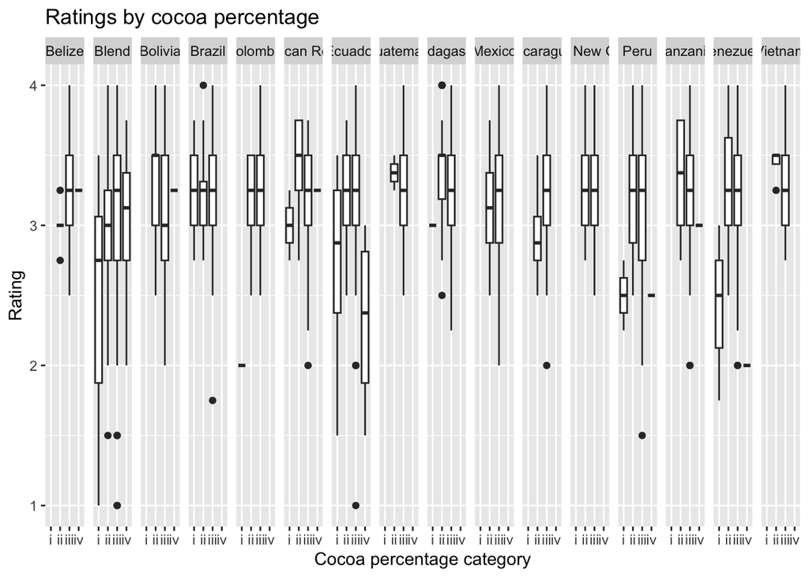

      ```r
      ggplot(chocolate_n6, aes(x = cat_chocolate_percentage, y= rating)) +
        geom_boxplot() +
        facet_grid(. ~ country_of_bean_origin) +
        ggtitle("Ratings by cocoa percentage") +
        xlab("Cocoa percentage category") +
        ylab("Rating")
      ```

      On average, which category of chocolate percentage is most highly rated? Do these countries mostly agree or are there disagreements?

      Answer: Categories ii and iii tend to be rated higher just by grossly inspecting the box plots. There appears to be some agreement across countries albeit not apparent.

## Part 2: Join two datasets together

The goal of this part of the assignment is to join two datasets together. `gapminder` is a [R package](https://cran.r-project.org/web/packages/gapminder/README.html) that contains an excerpt from the [Gapminder data](https://www.gapminder.org/data/).

```r
library(gapminder)
as_tibble(gapminder)
```

```
## # A tibble: 1,704 × 6
##    country     continent  year lifeExp      pop gdpPercap
##    <fct>       <fct>     <int>   <dbl>    <int>     <dbl>
##  1 Afghanistan Asia       1952    28.8  8425333      779.
##  2 Afghanistan Asia       1957    30.3  9240934      821.
##  3 Afghanistan Asia       1962    32.0 10267083      853.
##  4 Afghanistan Asia       1967    34.0 11537966      836.
##  5 Afghanistan Asia       1972    36.1 13079460      740.
##  6 Afghanistan Asia       1977    38.4 14880372      786.
##  7 Afghanistan Asia       1982    39.9 12881816      978.
##  8 Afghanistan Asia       1987    40.8 13867957      852.
##  9 Afghanistan Asia       1992    41.7 16317921      649.
## 10 Afghanistan Asia       1997    41.8 22227415      635.
## # ℹ 1,694 more rows
```

1. Use this dataset it to create a new column called `continent` in our `chocolate` dataset that contains the continent name for each review where the country of bean origin is.

   ```r
   country_to_continent <-data.frame(
     country_of_bean_origin = gapminder$country,
     continent = gapminder$continent,
     stringsAsFactors = TRUE
   )
   country_to_continent_unique <-unique(as_tibble(country_to_continent))

   chocolate_continent <- left_join(chocolate, country_to_continent_unique, by = "country_of_bean_origin")

   glimpse(chocolate_continent)
   ```

   ```
   ## Rows: 2,530
   ## Columns: 11
   ## $ ref                              <dbl> 2454, 2458, 2454, 2542, 2546, 2546, 2…
   ## $ company_manufacturer             <chr> "5150", "5150", "5150", "5150", "5150…
   ## $ company_location                 <chr> "U.S.A.", "U.S.A.", "U.S.A.", "U.S.A.…
   ## $ review_date                      <dbl> 2019, 2019, 2019, 2021, 2021, 2021, 2…
   ## $ country_of_bean_origin           <chr> "Tanzania", "Dominican Republic", "Ma…
   ## $ specific_bean_origin_or_bar_name <chr> "Kokoa Kamili, batch 1", "Zorzal, bat…
   ## $ cocoa_percent                    <chr> "76%", "76%", "76%", "68%", "72%", "8…
   ## $ ingredients                      <chr> "3- B,S,C", "3- B,S,C", "3- B,S,C", "…
   ## $ most_memorable_characteristics   <chr> "rich cocoa, fatty, bready", "cocoa, …
   ## $ rating                           <dbl> 3.25, 3.50, 3.75, 3.00, 3.00, 3.25, 3…
   ## $ continent                        <fct> Africa, Americas, Africa, NA, America…
   ```

2. Only keep reviews that have reviews from countries of bean origin with at least 10 reviews.

   ```r
   chocolate_continent_n <- chocolate_continent %>%
         mutate(n=1)

   chocolate_continent_n2 <- chocolate_continent_n %>%
         group_by(country_of_bean_origin) %>%
         mutate(n_by_origin_country=sum(n))

   chocolate_continent_n3 <- filter(chocolate_continent_n2, n_by_origin_country>=10)

   glimpse(chocolate_continent_n3)
   ```

   ```
   ## Rows: 2,448
   ## Columns: 13
   ## Groups: country_of_bean_origin [35]
   ## $ ref                              <dbl> 2454, 2458, 2454, 2542, 2546, 2546, 2…
   ## $ company_manufacturer             <chr> "5150", "5150", "5150", "5150", "5150…
   ## $ company_location                 <chr> "U.S.A.", "U.S.A.", "U.S.A.", "U.S.A.…
   ## $ review_date                      <dbl> 2019, 2019, 2019, 2021, 2021, 2021, 2…
   ## $ country_of_bean_origin           <chr> "Tanzania", "Dominican Republic", "Ma…
   ## $ specific_bean_origin_or_bar_name <chr> "Kokoa Kamili, batch 1", "Zorzal, bat…
   ## $ cocoa_percent                    <chr> "76%", "76%", "76%", "68%", "72%", "8…
   ## $ ingredients                      <chr> "3- B,S,C", "3- B,S,C", "3- B,S,C", "…
   ## $ most_memorable_characteristics   <chr> "rich cocoa, fatty, bready", "cocoa, …
   ## $ rating                           <dbl> 3.25, 3.50, 3.75, 3.00, 3.00, 3.25, 3…
   ## $ continent                        <fct> Africa, Americas, Africa, NA, America…
   ## $ n                                <dbl> 1, 1, 1, 1, 1, 1, 1, 1, 1, 1, 1, 1, 1…
   ## $ n_by_origin_country              <dbl> 79, 226, 177, 16, 253, 19, 35, 80, 24…
   ```

3. Also, remove the country of bean origin named `"Blend"`.

   ```r
   chocolate_continent_n4 <-filter(chocolate_continent_n3, country_of_bean_origin!="Blend")
   glimpse(chocolate_continent_n4)
   ```

   ```
   ## Rows: 2,292
   ## Columns: 13
   ## Groups: country_of_bean_origin [34]
   ## $ ref                              <dbl> 2454, 2458, 2454, 2542, 2546, 2546, 2…
   ## $ company_manufacturer             <chr> "5150", "5150", "5150", "5150", "5150…
   ## $ company_location                 <chr> "U.S.A.", "U.S.A.", "U.S.A.", "U.S.A.…
   ## $ review_date                      <dbl> 2019, 2019, 2019, 2021, 2021, 2021, 2…
   ## $ country_of_bean_origin           <chr> "Tanzania", "Dominican Republic", "Ma…
   ## $ specific_bean_origin_or_bar_name <chr> "Kokoa Kamili, batch 1", "Zorzal, bat…
   ## $ cocoa_percent                    <chr> "76%", "76%", "76%", "68%", "72%", "8…
   ## $ ingredients                      <chr> "3- B,S,C", "3- B,S,C", "3- B,S,C", "…
   ## $ most_memorable_characteristics   <chr> "rich cocoa, fatty, bready", "cocoa, …
   ## $ rating                           <dbl> 3.25, 3.50, 3.75, 3.00, 3.00, 3.25, 3…
   ## $ continent                        <fct> Africa, Americas, Africa, NA, America…
   ## $ n                                <dbl> 1, 1, 1, 1, 1, 1, 1, 1, 1, 1, 1, 1, 1…
   ## $ n_by_origin_country              <dbl> 79, 226, 177, 16, 253, 19, 35, 80, 24…
   ```

4. Make a set of violin plots with ratings on the y-axis and `continent`s on the x-axis.

   ```r
   chocolate_continent_n4$continent <-as.character(chocolate_continent_n4$continent)
   chocolate_continent_n4$continent[is.na(chocolate_continent_n4$continent)] <- "Other"
   chocolate_continent_n4$continent <- factor(chocolate_continent_n4$continent)
   glimpse(chocolate_continent_n4)
   ```

   ```
   ## Rows: 2,292
   ## Columns: 13
   ## Groups: country_of_bean_origin [34]
   ## $ ref                              <dbl> 2454, 2458, 2454, 2542, 2546, 2546, 2…
   ## $ company_manufacturer             <chr> "5150", "5150", "5150", "5150", "5150…
   ## $ company_location                 <chr> "U.S.A.", "U.S.A.", "U.S.A.", "U.S.A.…
   ## $ review_date                      <dbl> 2019, 2019, 2019, 2021, 2021, 2021, 2…
   ## $ country_of_bean_origin           <chr> "Tanzania", "Dominican Republic", "Ma…
   ## $ specific_bean_origin_or_bar_name <chr> "Kokoa Kamili, batch 1", "Zorzal, bat…
   ## $ cocoa_percent                    <chr> "76%", "76%", "76%", "68%", "72%", "8…
   ## $ ingredients                      <chr> "3- B,S,C", "3- B,S,C", "3- B,S,C", "…
   ## $ most_memorable_characteristics   <chr> "rich cocoa, fatty, bready", "cocoa, …
   ## $ rating                           <dbl> 3.25, 3.50, 3.75, 3.00, 3.00, 3.25, 3…
   ## $ continent                        <fct> Africa, Americas, Africa, Other, Amer…
   ## $ n                                <dbl> 1, 1, 1, 1, 1, 1, 1, 1, 1, 1, 1, 1, 1…
   ## $ n_by_origin_country              <dbl> 79, 226, 177, 16, 253, 19, 35, 80, 24…
   ```

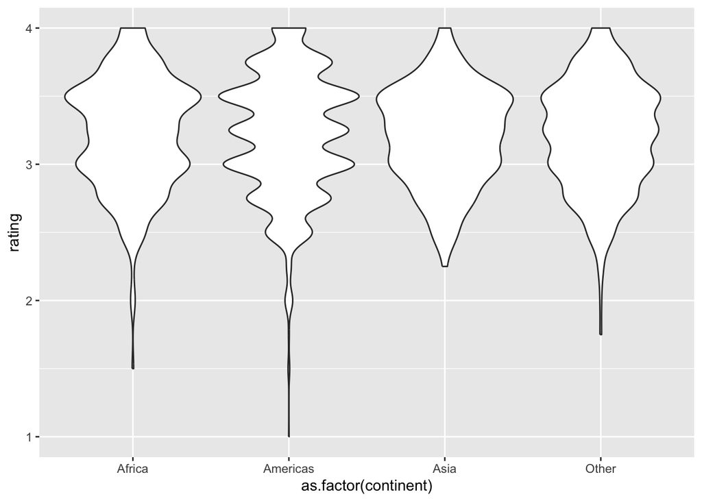

   ```r
   chocolate_continent_n4 %>%
       ggplot(aes(
           x = as.factor(continent),
           y = rating
       )) +
       geom_violin()
   ```

## Part 3: **Convert wide data into long data**

1. Create a new set of columns titled `beans`, `sugar`, `cocoa_butter`, `vanilla`, `letchin`, and `salt` that contain a 1 or 0 representing whether or not that review for the chocolate bar contained that ingredient (1) or not (0).

   ```r
   chocolate_part3<-chocolate %>%
     mutate(
       beans=NA,
       sugar=NA,
       cocoa_butter=NA,
       vanilla=NA,
       letchin=NA,
       salt=NA)

   for (i in 1:nrow(chocolate_part3)){

     if (length(grep("B",chocolate_part3$ingredients[i],ignore.case=TRUE))>0) {
       chocolate_part3$beans[i]<-1
     }
     else {
       chocolate_part3$beans[i]<-0
     }

     if (length(grep("S",chocolate_part3$ingredients[i],ignore.case=TRUE))>0) {
       chocolate_part3$sugar[i]<-1
     }
     else {
       chocolate_part3$sugar[i]<-0
     }

     if (length(grep("C",chocolate_part3$ingredients[i],ignore.case=TRUE))>0) {
       chocolate_part3$cocoa_butter[i]<-1
     }
     else {
       chocolate_part3$cocoa_butter[i]<-0
     }

     if (length(grep("V",chocolate_part3$ingredients[i],ignore.case=TRUE))>0) {
       chocolate_part3$vanilla[i]<-1
     }
     else {
       chocolate_part3$vanilla[i]<-0
     }

    if (length(grep("L",chocolate_part3$ingredients[i],ignore.case=TRUE))>0) {
       chocolate_part3$letchin[i]<-1
     }
     else {
       chocolate_part3$letchin[i]<-0
     }

     if (length(grep("Sa",chocolate_part3$ingredients[i],ignore.case=TRUE))>0) {
       chocolate_part3$salt[i]<-1
     }
     else {
       chocolate_part3$salt[i]<-0
     }
   }
   glimpse(chocolate_part3)
   ```

   ```
   ## Rows: 2,530
   ## Columns: 16
   ## $ ref                              <dbl> 2454, 2458, 2454, 2542, 2546, 2546, 2…
   ## $ company_manufacturer             <chr> "5150", "5150", "5150", "5150", "5150…
   ## $ company_location                 <chr> "U.S.A.", "U.S.A.", "U.S.A.", "U.S.A.…
   ## $ review_date                      <dbl> 2019, 2019, 2019, 2021, 2021, 2021, 2…
   ## $ country_of_bean_origin           <chr> "Tanzania", "Dominican Republic", "Ma…
   ## $ specific_bean_origin_or_bar_name <chr> "Kokoa Kamili, batch 1", "Zorzal, bat…
   ## $ cocoa_percent                    <chr> "76%", "76%", "76%", "68%", "72%", "8…
   ## $ ingredients                      <chr> "3- B,S,C", "3- B,S,C", "3- B,S,C", "…
   ## $ most_memorable_characteristics   <chr> "rich cocoa, fatty, bready", "cocoa, …
   ## $ rating                           <dbl> 3.25, 3.50, 3.75, 3.00, 3.00, 3.25, 3…
   ## $ beans                            <dbl> 1, 1, 1, 1, 1, 1, 1, 1, 1, 1, 1, 1, 1…
   ## $ sugar                            <dbl> 1, 1, 1, 1, 1, 1, 1, 1, 1, 1, 1, 1, 1…
   ## $ cocoa_butter                     <dbl> 1, 1, 1, 1, 1, 1, 1, 1, 1, 1, 1, 1, 1…
   ## $ vanilla                          <dbl> 0, 0, 0, 0, 0, 0, 0, 0, 0, 0, 0, 0, 0…
   ## $ letchin                          <dbl> 0, 0, 0, 0, 0, 0, 0, 1, 1, 1, 1, 1, 1…
   ## $ salt                             <dbl> 0, 0, 0, 0, 0, 0, 0, 0, 0, 0, 0, 0, 0…
   ```

2. Create a new set of columns titled `char_cocoa`, `char_sweet`, `char_nutty`, `char_creamy`, `char_roasty`, `char_earthy` that contain a 1 or 0 representing whether or not that the most memorable characteristic for the chocolate bar had that word (1) or not (0). For example, if the word “sweet” appears in the `most_memorable_characteristics`, then record a 1, otherwise a 0 for that review in the `char_sweet` column (**Hint**: check out `str_detect()` from the `stringr` package).

   ```r
   chocolate_part3_2<-chocolate_part3 %>%
     mutate(
       char_cocoa=NA,
       char_sweet=NA,
       char_nutty=NA,
       char_creamy=NA,
       char_roasty=NA,
       char_earthy=NA)

   for (i in 1:nrow(chocolate_part3_2)){

     if (length(grep("cocoa",chocolate_part3$most_memorable_characteristics[i],ignore.case=TRUE))>0) {
       chocolate_part3_2$char_cocoa[i]<-1
     }
     else {
       chocolate_part3_2$char_cocoa[i]<-0
     }

     if (length(grep("sweet",chocolate_part3$most_memorable_characteristics[i],ignore.case=TRUE))>0) {
       chocolate_part3_2$char_sweet[i]<-1
     }
     else {
       chocolate_part3_2$char_sweet[i]<-0
     }

     if (length(grep("nutty",chocolate_part3$most_memorable_characteristics[i],ignore.case=TRUE))>0) {
       chocolate_part3_2$char_nutty[i]<-1
     }
     else {
       chocolate_part3_2$char_nutty[i]<-0
     }

     if (length(grep("cream",chocolate_part3$most_memorable_characteristics[i],ignore.case=TRUE))>0) {
       chocolate_part3_2$char_creamy[i]<-1
     }
     else {
       chocolate_part3_2$char_creamy[i]<-0
     }

    if (length(grep("roasty",chocolate_part3$most_memorable_characteristics[i],ignore.case=TRUE))>0) {
       chocolate_part3_2$char_roasty[i]<-1
     }
     else {
       chocolate_part3_2$char_roasty[i]<-0
     }

    if (length(grep("earthy",chocolate_part3$most_memorable_characteristics[i],ignore.case=TRUE))>0) {
       chocolate_part3_2$char_earthy[i]<-1
     }
     else {
       chocolate_part3_2$char_earthy[i]<-0
     }
   }
   glimpse(chocolate_part3_2)
   ```

   ```
   ## Rows: 2,530
   ## Columns: 22
   ## $ ref                              <dbl> 2454, 2458, 2454, 2542, 2546, 2546, 2…
   ## $ company_manufacturer             <chr> "5150", "5150", "5150", "5150", "5150…
   ## $ company_location                 <chr> "U.S.A.", "U.S.A.", "U.S.A.", "U.S.A.…
   ## $ review_date                      <dbl> 2019, 2019, 2019, 2021, 2021, 2021, 2…
   ## $ country_of_bean_origin           <chr> "Tanzania", "Dominican Republic", "Ma…
   ## $ specific_bean_origin_or_bar_name <chr> "Kokoa Kamili, batch 1", "Zorzal, bat…
   ## $ cocoa_percent                    <chr> "76%", "76%", "76%", "68%", "72%", "8…
   ## $ ingredients                      <chr> "3- B,S,C", "3- B,S,C", "3- B,S,C", "…
   ## $ most_memorable_characteristics   <chr> "rich cocoa, fatty, bready", "cocoa, …
   ## $ rating                           <dbl> 3.25, 3.50, 3.75, 3.00, 3.00, 3.25, 3…
   ## $ beans                            <dbl> 1, 1, 1, 1, 1, 1, 1, 1, 1, 1, 1, 1, 1…
   ## $ sugar                            <dbl> 1, 1, 1, 1, 1, 1, 1, 1, 1, 1, 1, 1, 1…
   ## $ cocoa_butter                     <dbl> 1, 1, 1, 1, 1, 1, 1, 1, 1, 1, 1, 1, 1…
   ## $ vanilla                          <dbl> 0, 0, 0, 0, 0, 0, 0, 0, 0, 0, 0, 0, 0…
   ## $ letchin                          <dbl> 0, 0, 0, 0, 0, 0, 0, 1, 1, 1, 1, 1, 1…
   ## $ salt                             <dbl> 0, 0, 0, 0, 0, 0, 0, 0, 0, 0, 0, 0, 0…
   ## $ char_cocoa                       <dbl> 1, 1, 1, 0, 0, 1, 0, 0, 0, 0, 0, 0, 0…
   ## $ char_sweet                       <dbl> 0, 0, 0, 0, 0, 0, 0, 0, 0, 0, 0, 0, 0…
   ## $ char_nutty                       <dbl> 0, 0, 0, 0, 1, 0, 0, 1, 0, 1, 0, 0, 0…
   ## $ char_creamy                      <dbl> 0, 0, 0, 0, 0, 0, 0, 0, 0, 0, 0, 0, 0…
   ## $ char_roasty                      <dbl> 0, 0, 0, 0, 0, 0, 0, 0, 1, 0, 0, 0, 0…
   ## $ char_earthy                      <dbl> 0, 0, 0, 0, 1, 0, 0, 0, 0, 1, 0, 0, 0…
   ```

3. For each year (i.e. `review_date`), calculate the mean value in each new column you created across all reviews for that year. (**Hint**: If all has gone well thus far, you should have a dataset with 16 rows and 13 columns).

   ```r
     data_by_year <- chocolate_part3_2 %>%
       group_by(review_date) %>%
       summarize(
         mean_beans = mean(beans, na.rm = TRUE),
         mean_sugar = mean(sugar, na.rm = TRUE),
         mean_cocoa_butter = mean(cocoa_butter, na.rm = TRUE),
         mean_vanilla = mean(vanilla, na.rm = TRUE),
         mean_letchin = mean(letchin, na.rm = TRUE),
         mean_salt = mean(salt, na.rm = TRUE),
         mean_char_cocoa = mean(char_cocoa, na.rm = TRUE),
         mean_char_sweet = mean(char_sweet, na.rm = TRUE),
         mean_char_nutty = mean(char_nutty, na.rm = TRUE),
         mean_char_creamy = mean(char_creamy, na.rm = TRUE),
         mean_char_roasty = mean(char_roasty, na.rm = TRUE),
         mean_char_earthy = mean(char_earthy, na.rm = TRUE)
       )
     print(data_by_year)
   ```

   ```
   ## # A tibble: 16 × 13
   ##    review_date mean_beans mean_sugar mean_cocoa_butter mean_vanilla mean_letchin
   ##          <dbl>      <dbl>      <dbl>             <dbl>        <dbl>        <dbl>
   ##  1        2006      0.968      0.968             0.903       0.694        0.694
   ##  2        2007      0.945      0.945             0.767       0.548        0.384
   ##  3        2008      0.913      0.902             0.75        0.359        0.511
   ##  4        2009      0.919      0.919             0.772       0.325        0.341
   ##  5        2010      0.855      0.855             0.709       0.227        0.391
   ##  6        2011      0.939      0.939             0.693       0.160        0.160
   ##  7        2012      0.928      0.928             0.675       0.186        0.124
   ##  8        2013      0.967      0.956             0.776       0.208        0.295
   ##  9        2014      0.984      0.984             0.644       0.0688       0.121
   ## 10        2015      0.986      0.979             0.546       0.0599       0.120
   ## 11        2016      0.982      0.977             0.594       0.0507       0.106
   ## 12        2017      0.981      0.981             0.562       0.0286       0.133
   ## 13        2018      0.987      0.987             0.596       0.0614       0.132
   ## 14        2019      1          1                 0.679       0.0259       0.202
   ## 15        2020      1          1                 0.568       0.0370       0.0247
   ## 16        2021      1          0.994             0.646       0.0114       0.0800
   ## # ℹ 7 more variables: mean_salt <dbl>, mean_char_cocoa <dbl>,
   ## #   mean_char_sweet <dbl>, mean_char_nutty <dbl>, mean_char_creamy <dbl>,
   ## #   mean_char_roasty <dbl>, mean_char_earthy <dbl>
   ```

4. Convert this wide dataset into a long dataset with a new `feature` and `mean_score` column.

   ```r
   data_by_year_long <- data_by_year %>%
        pivot_longer(
            cols = starts_with("mean_"),
            names_to = c("mean", "feature1", "feature"),
            names_sep = "_"
        )
   data_by_year_long <- data_by_year_long %>%
     rename(
          mean_score = value
       )

   for (i in 1:nrow(data_by_year_long)) {
     if (is.na(data_by_year_long$feature[i])==FALSE) {
      data_by_year_long$feature[i] = paste0("char_", data_by_year_long$feature[i])
     }
     else {
       data_by_year_long$feature[i] = data_by_year_long$feature1[i]
     }
   }

   data_by_year_long<- data_by_year_long %>%
     select(-mean, -feature1)

   print(data_by_year_long)
   ```

   ```
   ## # A tibble: 192 × 3
   ##    review_date feature     mean_score
   ##          <dbl> <chr>            <dbl>
   ##  1        2006 beans           0.968
   ##  2        2006 sugar           0.968
   ##  3        2006 char_butter     0.903
   ##  4        2006 vanilla         0.694
   ##  5        2006 letchin         0.694
   ##  6        2006 salt            0
   ##  7        2006 char_cocoa      0.210
   ##  8        2006 char_sweet      0.161
   ##  9        2006 char_nutty      0.0323
   ## 10        2006 char_creamy     0.242
   ## # ℹ 182 more rows
   ```

## Part 4: **Data visualization**

Use the functions in `ggplot2` package to make a scatter plot of the `mean_score`s (y-axis) over time (x-axis). There should be one plot (facet) for each `feature`. For full credit, your plot should include:

1. An overall title for the plot and a subtitle summarizing key trends that you found. Also include a caption in the figure with your name.
2. Both the observed points for the `mean_score`, but also a smoothed non-linear pattern of the trend
3. All plots should be shown in the one figure
4. There should be an informative x-axis and y-axis label

Consider playing around with the `theme()` function to make the figure shine, including playing with background colors, font, etc. See https://github.com/lcolladotor/jhustatcomputing/issues/4 for an example on how you can choose colors if you have too many categories.

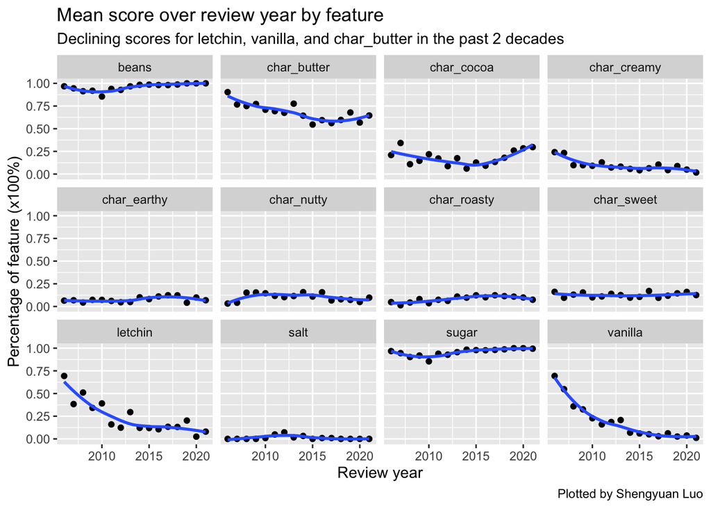

```r
plot_part4 <- ggplot(data_by_year_long, aes(x = review_date, y = mean_score)) +
  geom_point() +
  geom_smooth(se = FALSE) +
  facet_wrap(~ feature) +
  labs(
    title = "Mean score over review year by feature",
    subtitle = "Declining scores for letchin, vanilla, and char_butter in the past 2 decades",
    caption = "Plotted by Shengyuan Luo",
        x = "Review year",
        y = "Percentage of feature (x100%)"
  )
plot_part4
```

## Part 5: **Make the worst plot you can!**

Using the `chocolate` dataset (or any of the modified versions you made throughout this assignment or anything else you wish you build upon it):

1. Make the absolute worst plot that you can. You need to customize it in **at least 7 ways** to make it awful.
2. In your document, write 1 - 2 sentences about each different customization you added (using bullets – i.e. there should be at least 7 bullet points each with 1-2 sentences), and how it could be useful for you when you want to make an awesome data visualization.

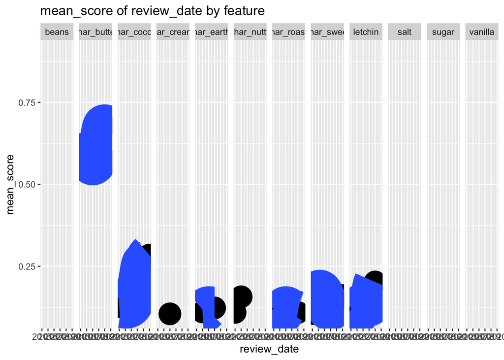

   ```r
   plot_part4_worst <- ggplot(data_by_year_long, aes(x = review_date, y = mean_score)) +
     geom_point(      size = 10) +
     geom_smooth(    linewidth = 20,se = FALSE) +
     facet_grid(. ~ feature) +
     labs(
       title = "mean_score of review_date by feature"
     ) +
     ylim(0.1, 0.9) +
     xlim(2015, 2020)
   plot_part4_worst
   ```

   Customization:
   1. Absence of x- and y- labels. Axis labels can help readers understand the graph much more easily.
   2. Uninformative overall title. Same as axis labels, an informative label makes the graph friendlier to readers.
   3. Oversized scatter plot points. Optimizing the size of points help preserve information and make plots more aesthestic.
   4. Oversized line. Same as points, optimizing regression lines help the illustration of data and make plots more aesthestic.
   5. Over-crowded facets in one row. An optimal facet grid to evenly distribute data improves data visualization.
   6. Bad y-axis range. An ideal y-axis range helps readers focus on the most important parts of data.
   7. Bad x-axis range. Like y-axis, setting the range for the x-axis help demonstrate the most important data that the author wants to present.

## Part 6: **Make my plot a better plot!**

The goal is to take my sad looking plot and make it better! If you’d like an [example](https://twitter.com/drmowinckels/status/1392136510468763652), here is a tweet I came across of someone who gave a talk about how to zhoosh up your ggplots.

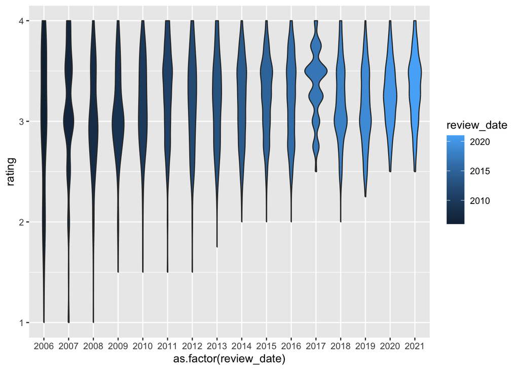

```r
chocolate %>%
    ggplot(aes(
        x = as.factor(review_date),
        y = rating,
        fill = review_date
    )) +
    geom_violin()
```

1. You need to customize it in **at least 7 ways** to make it better.
2. In your document, write 1 - 2 sentences about each different customization you added (using bullets – i.e. there should be at least 7 bullet points each with 1-2 sentences), describing how you improved it.

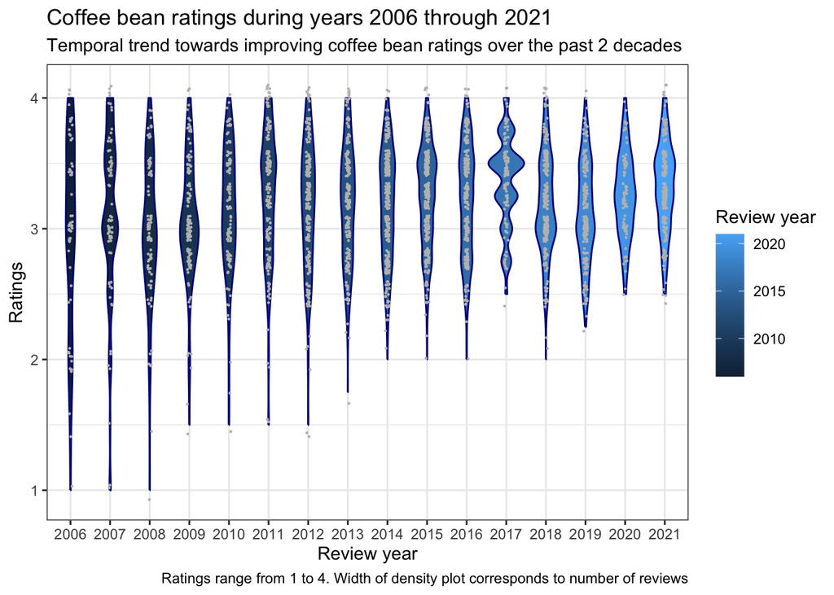

   ```r
   chocolate_better <- chocolate %>%
       ggplot(aes(
           x = as.factor(review_date),
           y = rating,
           fill = review_date
       )) +
     labs(
       title = "Coffee bean ratings during years 2006 through 2021",
       subtitle = "Temporal trend towards improving coffee bean ratings over the past 2 decades",
       caption = "Ratings range from 1 to 4. Width of density plot corresponds to number of reviews",
       fill = "Review year",
           x = "Review year",
           y = "Ratings"
     ) +
         geom_violin(color = "dark blue") +
     geom_jitter(width = 0.05, size = 0.15, color = "grey")+
     theme_bw(
     )
   chocolate_better
   ```

   Customizations:
   1. Add title and subtitle to help understand the graph.
   2. Add descriptive axis labels.
   3. Add caption to further explain ratings.
   4. Make outline of violins dark blue so they look more aesthetically pleasing.
   5. Change background to black/white to make the graph more stark/plain.
   6. Overlie jitter dots to further enhance the plot.
   7. Change legend title to “review year” to replace original variable name.

# **R session information**

```r
options(width = 120)
```